# 로지스틱 이항분류

## 로지스틱 회귀모형

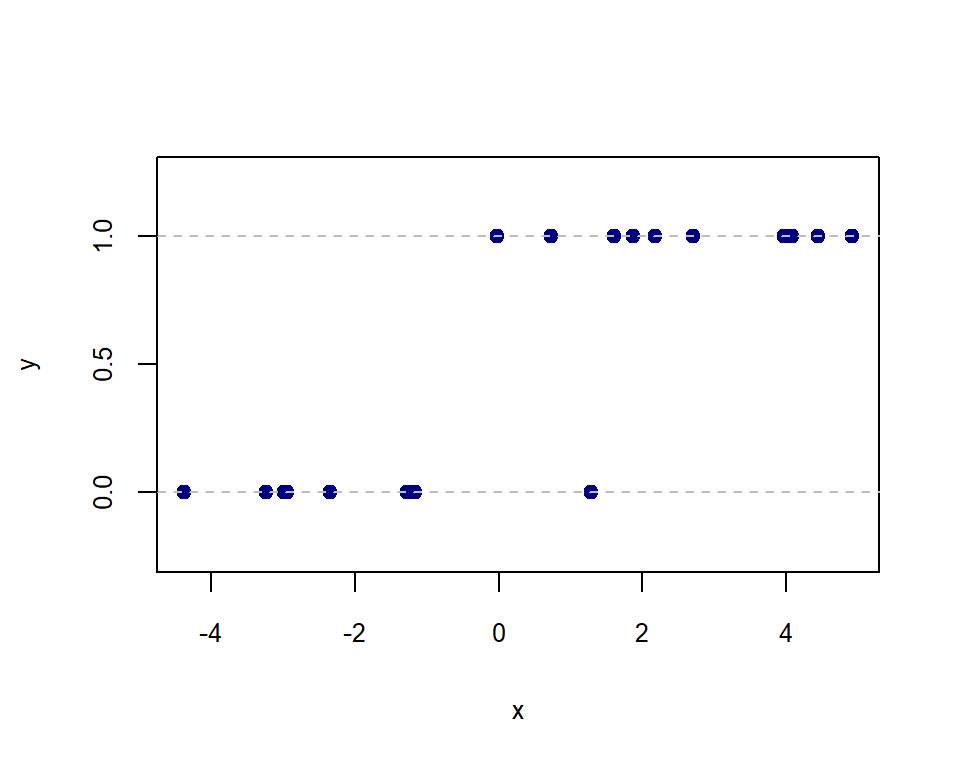

위 그림과 같이 타겟변수 $y$가 이항변수인 경우, 즉 $y=0$ 또는 $y=1$인 경우 이를 예측하기 위한 회귀모형에 대해 생각해보자. 그림을 살펴보면 $x$의 값이 클 수록 $y$의 값이 큰 경향이 뚜렷하다. 따라서 두 변수 사이의 함수식으로 앞 절에서 살펴본 선형회귀모형, 즉 기울기가 양수인 직선식을 $y$를 예측하기 위한 모형식으로 사용하는 것을 고려할 만하다.

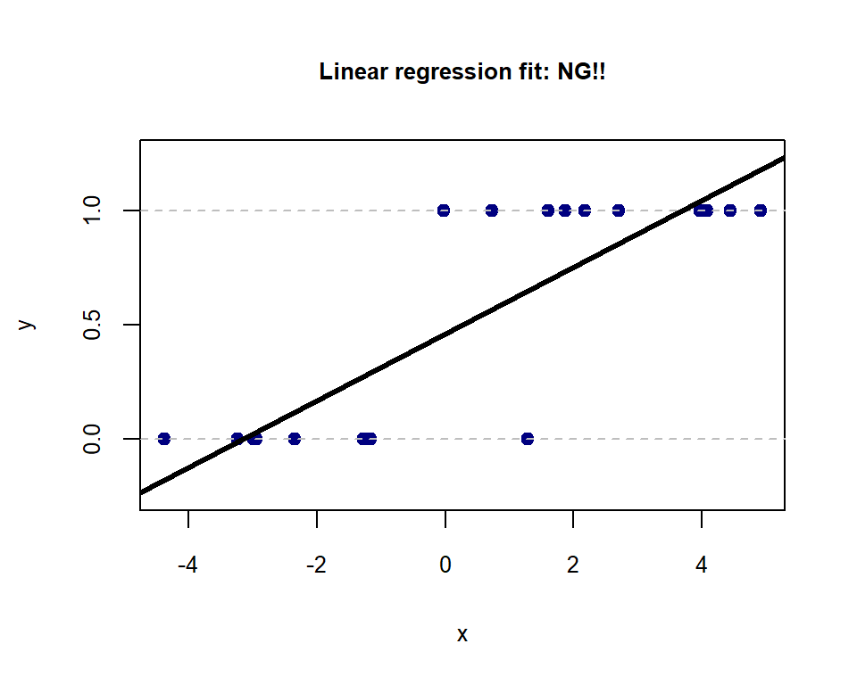

그러나 이 방법은 모형이 내어놓는 예측값이 실수값이기 때문에 이 문제에 그대로 적용하는 것은 곤란하다. (예를 들어 0.35이나 -1.5와 같은 값이 $y$의 예측값으로 도출되었다면, 이 값을 이항변수 $y$의 예측에 어떻게 사용하는 것이 좋을 것인가?) 대신 그 값을 $y$가 1이 되는 가능성을 숫자화한 점수(score)로 사용해, 모형이 도출한 예측값이 크다면 $y$의 값을 1로 예측하고, 작다면 0으로 예측하는 것 정도가 자연스러운 생각일 것이다.

이 문제에 대한 구체적 해답을 찾기 위해 우선 타겟변수 $y$가 연속형인 경우의 회귀함수 $E(y|{\boldsymbol x})$로부터 논의를 시작해보자. 선형회귀에서는 이 조건부평균을 ${\boldsymbol x}$에 대한 선형식으로 놓은 모형을 학습했다. 타겟변수 $y$가 이항변수인 경우 조건부평균을 따져보면
$$E(y|{\boldsymbol x})
= \sum_{y=0}^1 y P(y|{\boldsymbol x})
= 0\times P(y = 0|{\boldsymbol x}) + 1\times P(y = 1|{\boldsymbol x})
= P(y = 1|{\boldsymbol x})$$
로서, 학습해야 하는 회귀함수가 조건부”**확률**”값을 도출해줘야 한다. 따라서 그 값이 0과 1사이의 범위로 제한되기 때문에 이 함수에 대해 ${\boldsymbol x}$에 대한 선형식
$$f(\boldsymbol x)
= w_0 + \sum_{j=1}^d w_j x_j$$
를 가정하는 것은 적절치 않다.

이에 $\boldsymbol x$에 대한 선형함수 $f$에 시그모이드함수(sigmoid function)라 불리는 함수를 합성한 것을 회귀함수식으로 사용하는 확장 모형을 고려해보자.
$$(\sigma\circ f)(\boldsymbol x)
= \sigma\left(f(\boldsymbol x)\right)
= \sigma\left(w_0 + \sum_{j=1}^d w_j x_j \right)$$
단, $\sigma(s) = 1/(1 + e^{-s})$이다.

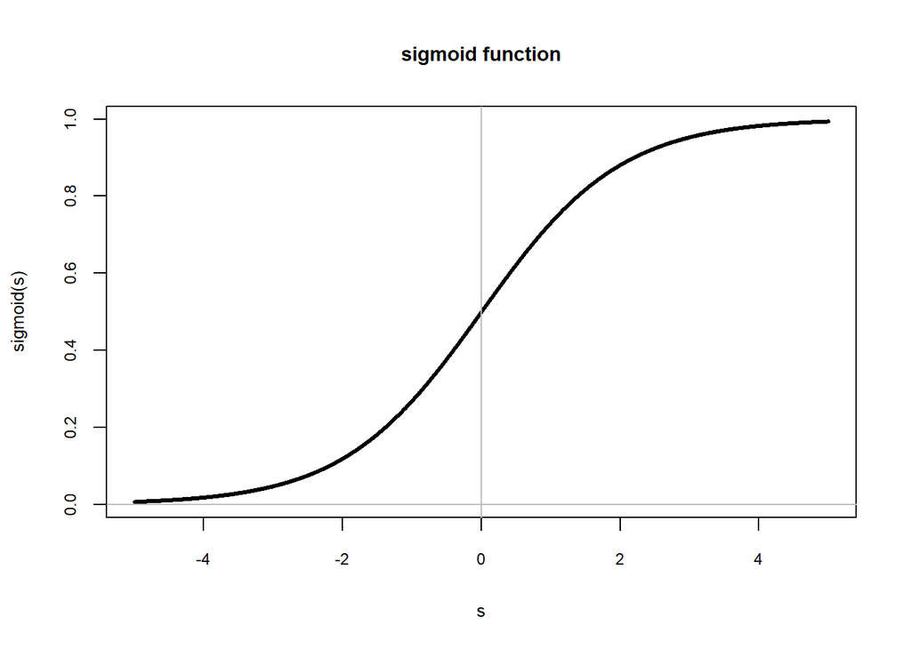

위 그림에 제시된 시그모이드 함수의 개형에서 확인할 수 있는 바와 같이, 시그모이드함수는 실수 전체 영역에서 증가함수이고 0과 1 사이의 값을 갖는다. 따라서 위 확장모형을 통해 도출된 예측값 역시 0과 1사이의 숫자가 되며, 이 값은 주어진 $\boldsymbol x$값에 대응되는 $y$의 값이 1일 가능성 또는 경향성에 대한 점수를 선형모형 $f({\boldsymbol x})$를 사용해 구한 뒤 시그모이드함수를 이용해 0과 1 사이의 숫자로 정규화한 것으로 해석할 수 있다.
$${\boldsymbol x}\stackrel{\tiny\mbox{scoring}}{\longrightarrow}
f(\boldsymbol x) \stackrel{\tiny\mbox{normalization}}{\longrightarrow}
\sigma\left(f(\boldsymbol x)\right)$$

**로지스틱회귀모형(logistic regression model)**은 이렇게 얻은 함수를 주어진 $\boldsymbol x$값에 대응되는 조건부확률 $P(y = 1|{\boldsymbol x})$을 위한 모형으로 사용하는 것이다.
$$P(y = 1|{\boldsymbol x}) = \sigma\left(w_0 + \sum_{j=1}^d w_j x_j\right)$$
시그모이드함수의 역함수를 로짓함수(logit function)라 하는데
$${\sf logit}(p) \equiv \sigma^{-1}(p) = \log\frac{p}{1 - p}\quad (0 <
p < 1)$$
가 됨을 쉽게 확인할 수 있다. 따라서 로지스틱회귀모형은 로짓함수를 사용해 다음과 같이 선형모형의 형태로 나타낼 수 있다.
$${\sf logit}\Big(P(y = 1|{\boldsymbol x})\Big)
= \log\frac{P(y = 1|{\boldsymbol x})}{1 - P(y = 1|{\boldsymbol x})}
= w_0 + \sum_{j=1}^d w_j x_j$$

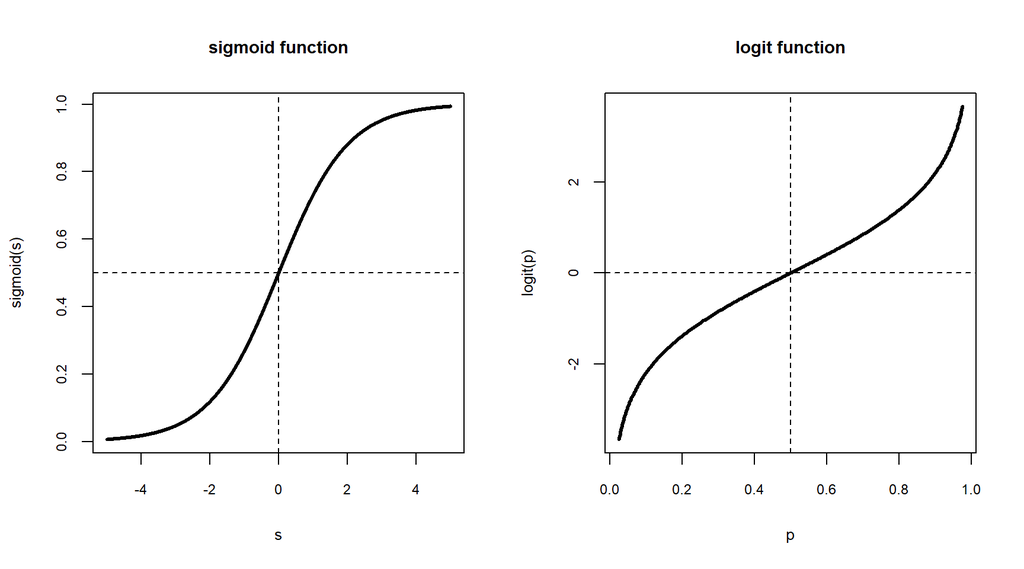

${\sf logit}\left(P(y=1|{\boldsymbol x})\right)$의 계산 과정에 등장하는
$$\frac{P(y = 1|{\boldsymbol x})}{1 - P(y = 1|{\boldsymbol x})}
= \frac{P(y = 1|{\boldsymbol x})}{P(y = 0|{\boldsymbol x})}$$
를 오즈비(odds ratio)라 한다. 따라서 로지스틱회귀모형은 오즈비의 로그값(로그-오즈비)에 대한 선형모형으로도 이해할 수 있다. 그리고 회귀계수 $w_j$은 로그-오즈비를 기준으로 해석하면 된다. 예를 들어 세 번째 예측변수 $x_3$에 대한 회귀계수 $w_3$의 값이 +1.2였다면, 다른 예측변수의 값이 동일한 수준으로 통제된 상태에서 $x_3$가 한 단위 증가하면 로그-오즈비가 1.2만큼 증가함을 의미하므로, $x_3$가 한 단위 증가함에 따라 오즈비는 $e^{1.2} = 3.32$배가 됨을 의미하게 된다. 오즈비 $p/(1-p)$는 $p$에 대해 증가함수이므로, 위 모형에서 도출된 오즈비를 $y=1$이 되는 경향성을 측정하는 점수로 사용할 수 있다. 만약 오즈비를 $y=1$이 되는 경향성에 대한 점수로 사용한다면 $x_3$가 한 단위 증가함에 따라 $y=1$이 되는 경향성이 3.32배로 증가한다고 해석할 수 있다.

로지스틱회귀모형을 이용해 $y$의 값을 예측하려면, 도출된 확률에 적절한 절단값을 적용하는 방식을 사용한다. 예를 들어 절단값을 0.5(=1/2)로 정하면 모형에 의해 예측된 확률이 0.5 이상이면 $y=1$로, 그렇지 않으면 $y=0$으로 예측하게 된다.

다음 그림은 위에서 제시된 예제 데이터에 대해 로지스틱회귀모형을 학습시켜 얻은 결과를 나타낸 것이다.

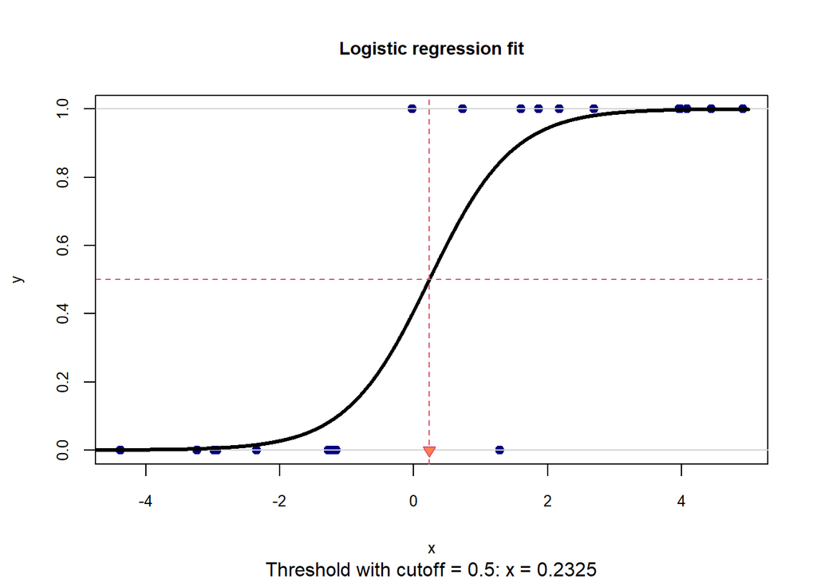

**참고:** 선형회귀식에 $y$의 값의 성격에 따라 적절한 함수를 합성한 모형을 **일반화선형모형(generalized linear model, GLM)**이라 한다. GLM에서 회귀함수식이 선형회귀식이 되도록 만들어 주는 함수를 연결함수(link function)이라 한다. 따라서 로지스틱회귀모형은 로짓함수를 연결함수로 하는 일반화선형모형이다. 앞 절에서 다룬 선형회귀모형 역시 연결함수가 항등함수인 일반화선형모형에 해당한다. 일반화선형모형의 다른 중요한 예로 포아송회귀모형이 있다. $y$의 성격이 계수형 자료(count data)인 경우에 사용하는 모형인데 로그함수를 연결함수로 사용한다.

## 로지스틱 회귀모형의 학습

### 데이터

$${\cal D} = \{({\boldsymbol x}_n, y_n)\,|\,n=1,2,...,N\} \subset
\mathbb{R}^d\times \{0, 1\}$$

- 인덱스 집합
  $$I = \{1, 2, ..., N\}$$

### 학습데이터

$${\cal D}_{\sf tr} = \{({\boldsymbol x}_n, y_n)\in{\cal D}\,|\,n\in
I_{\sf tr}\}$$
단, $I_{\sf tr}\subset I$이고 ${\sf card}(I_{\sf tr}) = N_{\sf tr}$이다.

### 손실함수

분류문제이므로 교차엔트로피를 손실함수로 사용한다. 이항변수인 $y$를 one-hot encoding 한 것을 $\boldsymbol{y} = (y_1, y_2)$라 하고, 학습된 모형이 제공하는 클래스 확률을 $\tilde{\boldsymbol y} = (\tilde{y}_1, \tilde{y}_2)$라 하면 교차엔트로피는
$$L(\tilde{\boldsymbol y}, \boldsymbol{y})
= -(y_1 \log\tilde{y}_1 + y_2 \log\tilde{y}_2)$$
이다.

- **예**

  | $n$ | 관측값(실제 클래스) $y_n$ | 원-핫 인코딩 ${\boldsymbol y}_n$ | 학습된 클래스 확률 $\tilde{\boldsymbol y}_n$ | 교차엔트로피 $L(\tilde{\boldsymbol y}, \boldsymbol{y})$ |
  | --- | --- | --- | --- | --- |
  | 1 | $0$ | $(1, 0)$ | $(0.8, 0.2)$ | $-\log 0.8$ |
  | 3 | $1$ | $(0, 1)$ | $(0.2, 0.8)$ | $-\log 0.8$ |
  | 4 | $1$ | $(0, 1)$ | $(0.4, 0.6)$ | $-\log 0.6$ |
  | 8 | $0$ | $(1, 0)$ | $(0.5, 0.5)$ | $-\log 0.5$ |
  | 13 | $1$ | $(0, 1)$ | $(0.3, 0.7)$ | $-\log 0.7$ |
  | $\vdots$ | $\vdots$ | $\vdots$ | $\vdots$ | $\vdots$ |

학습에 사용하는 목적함수는 학습데이터로 구한 교차엔트로피의 평균(또는 합)이 된다.
$${\cal L}(\boldsymbol{w})
= \frac{1}{N_{\sf tr}}\sum_{n\in I_{\sf tr}} L(\tilde{\boldsymbol
y}_{n}, {\boldsymbol y}_n)$$

위 식이 로지스틱 회귀모형의 경우 어떻게 되는 지 알아보자. $\tilde{\boldsymbol x} = \left[\begin{array}{c} 1 \\ {\boldsymbol x}\end{array}\right]$, $\boldsymbol{w} = (w_0, w_1, ..., w_d)^\top$라 하면,
$$y_{n,1} = 1 - y_n,\quad y_{n, 2} = y_n;$$
$$\begin{eqnarray*}
\tilde{y}_{n,1}
&\equiv& P(y_n = 0\,|\,{\boldsymbol x}_n)
= 1 - \sigma\left(\tilde{\boldsymbol x}_n^\top {\boldsymbol{w}}
\right),\\
\tilde{y}_{n,2}
&\equiv& P(y_n = 1\,|\,{\boldsymbol x}_n)
= \sigma\left(\tilde{\boldsymbol x}_n^\top {\boldsymbol{w}} \right)
\end{eqnarray*}$$
등이 성립하므로
$${\cal L}(\boldsymbol{w})
= - \frac{1}{N_{\sf tr}} \sum_{n\in I_{\sf tr}} \left[ y_n \log
\sigma\left(\tilde{\boldsymbol x}_n^\top {\boldsymbol{w}} \right) + (1
- y_n) \log \left\{1 - \sigma\left(\tilde{\boldsymbol x}_n^\top
{\boldsymbol{w}} \right)\right\}\right]$$
가 된다. 학습 목표는 위의 목적함수를 최소로 하는 $\boldsymbol{w}$, 즉
$$\hat{\boldsymbol{w}} = {\sf argmin}_{\boldsymbol{w}\in\mathbb{R}^{d+1}}
{\cal L}(\boldsymbol{w})$$
을 찾는 것이 된다.

**참고** 로지스틱회귀모형에서 주어진 $\boldsymbol x$에 대한 $y$값은 성공확률이 $\tilde{y}\equiv \sigma\left(\tilde{\boldsymbol x}^\top {\boldsymbol{w}} \right) = P(y = 1\,|\,{\boldsymbol x})$인 베르누이분포(Bernoulli distribution)를 따른다. 즉,
$$y|{\boldsymbol x} \sim {\sf Bernoulli}(\tilde{y}).$$
이 분포의 확률질량함수는
$$p(y|{\boldsymbol x}) = \tilde{y}^y \, (1 - \tilde{y})^{1-y}$$
이므로
$$\log p(y|{\boldsymbol x})
= y\log\tilde{y} + (1-y)\log(1 - \tilde{y})
= -\mbox{(cross-entropy)}$$
가 성립한다. 즉,
$$\begin{eqnarray*}
\ell(\boldsymbol{w})
&=& \sum_{n\in I_{\sf tr}}\log p(y_n|{\boldsymbol x}_n) \\
&=& \sum_{n\in I_{\sf tr}}\left[ y_n \log
\sigma\left(\tilde{\boldsymbol x}_n^\top {\boldsymbol{w}} \right) + (1
- y_n) \log \left\{1 - \sigma\left(\tilde{\boldsymbol x}_n^\top
{\boldsymbol{w}} \right)\right\}\right] \\
&=& -{N_{\sf tr}}\cdot{\cal L}(\boldsymbol{w})
\end{eqnarray*}$$
이 되므로, 학습데이터에 대해 구한 교차엔트로피의 평균인 ${\cal L}(\boldsymbol{w})$을 최소로 하는 $\boldsymbol{w}$를 찾는 것은 로그가능도함수 $\ell(\boldsymbol{w})$를 최대로 하는 **최대가능도방법(maximum likelihood method)과 동치**임을 알 수 있다.

### 경사하강법을 이용한 학습

목적함수 ${\cal L}(\boldsymbol{w})$를 최소로 하는 $\boldsymbol{w}$를 해석적으로 구하는 것은 불가능하다. 따라서 반복 알고리즘을 통해 근사적 해를 구할 수 밖에 없다. 여러 방안이 있지만 가장 간단한 방법인 경사하강법
$${\boldsymbol{w}} \leftarrow {\boldsymbol{w}} - \eta \nabla {\cal
L}({\boldsymbol{w}})$$
을 이용해 로지스틱 회귀모형을 학습하는 방법에 대해 생각해보자. 우선 ${\cal L}$의 그래디언트
$$\nabla {\cal L (\boldsymbol{w})}
= \frac{1}{N_{\sf tr}}\sum_{n\in I_{\sf tr}} \nabla L(\tilde{\boldsymbol
y}_n, {\boldsymbol y}_n)
= - \frac{1}{N_{\sf tr}}\sum_{n\in I_{\sf tr}} \left\{ y_n \nabla \log
\sigma\left(\tilde{\boldsymbol x}_n^\top\boldsymbol{w}\right) + (1 -
y_n) \nabla \log \left(1 - \sigma\left(\tilde{\boldsymbol
x}_n^\top\boldsymbol{w}\right)\right) \right\}$$
를 계산해보자. 이를 위해
$$\sigma(s)' = \sigma(s) \left\{1 - \sigma(s)\right\}$$
임을 이용하면 편리하다. 즉, 합성함수 미분법에 의해
$$\begin{eqnarray*}
& & \nabla \log \sigma\left(\tilde{\boldsymbol
x}_n^\top\boldsymbol{w}\right)
= \frac{\sigma(\tilde{\boldsymbol x}_n^\top\boldsymbol{w})(1 -
\sigma(\tilde{\boldsymbol
x}_n^\top\boldsymbol{w}))}{\sigma(\tilde{\boldsymbol
x}_n^\top\boldsymbol{w})}\times\tilde{\boldsymbol x}_n
= \left\{1 - \sigma(\tilde{\boldsymbol
x}_n^\top\boldsymbol{w})\right\}\,\tilde{\boldsymbol x}_n;\\
& & \nabla \log \left(1 - \sigma(\tilde{\boldsymbol
x}_n^\top\boldsymbol{w})\right)
= -\frac{\sigma(\tilde{\boldsymbol x}_n^\top\boldsymbol{w})(1 -
\sigma(\tilde{\boldsymbol x}_n^\top\boldsymbol{w}))}{1 -
\sigma(\tilde{\boldsymbol
x}_n^\top\boldsymbol{w})}\times\tilde{\boldsymbol x}_n
= -\sigma(\tilde{\boldsymbol
x}_n^\top\boldsymbol{w})\,\tilde{\boldsymbol x}_n
\end{eqnarray*}$$
가 성립한다. 즉,
$$\begin{eqnarray*}
\nabla L(\tilde{\boldsymbol y}_n, {\boldsymbol y}_n)
&=& -\left[ y_n \left\{ 1 - \sigma\left(\tilde{\boldsymbol
x}_n^\top \boldsymbol{w} \right)\right\} - (1 - y_n)
\sigma\left(\tilde{\boldsymbol x}_n^\top \boldsymbol{w}\right) \right]\,
\tilde{\boldsymbol x}_n \\
&=& -\left\{ y_n - \sigma\left(\tilde{\boldsymbol x}_n^\top
\boldsymbol{w} \right)\right\}\, \tilde{\boldsymbol x}_n
\end{eqnarray*}$$

가 성립하고, 따라서 목적함수 $\cal L$의 그래디언트는
$$\nabla {\cal L} (\boldsymbol{w})
= - \frac{1}{N_{\sf tr}}\sum_{n\in I_{\sf tr}}
\left\{ y_n - \sigma\left(\tilde{\boldsymbol x}_n^\top \boldsymbol{w}
\right)\right\}\, \tilde{\boldsymbol x}_n$$
이다. 이렇게 해서 로지스틱 회귀모형 학습을 위한 경사하강 알고리즘은 다음과 같은 업데이트 공식으로 주어진다.
$$\boldsymbol{w} \,\leftarrow\, \boldsymbol{w} + \eta\cdot\frac{1}{N_{\sf
tr}}\sum_{n\in I_{\sf tr}} \left\{ y_n - \sigma\left(\tilde{\boldsymbol
x}_n^\top \boldsymbol{w} \right)\right\}\, \tilde{\boldsymbol x}_n$$

**경사하강(gradient descent, GD) 알고리즘**

1. (초기화) 난수를 발생시켜 $\boldsymbol{w}$의 초기치를 정한다.
2. (업데이트)
   $$\boldsymbol{w} \,\leftarrow\, \boldsymbol{w} + \eta\cdot\frac{1}{N_{\sf
   tr}}\sum_{n\in I_{\sf tr}} \left\{ y_n - \sigma\left(\tilde{\boldsymbol
   x}_n^\top \boldsymbol{w} \right)\right\}\, \tilde{\boldsymbol x}_n$$
3. (반복) 수렴할 때까지 단계 2를 반복한다.

#### 모의실험 예제

모의실험으로 학습데이터를 생성하고 경사하강 알고리즘을 이용해 로지스틱 회귀모형을 학습시켜보자. 데이터를 생성하는 모의실험 세팅은 다음과 같다.

- $N_{\sf tr} = 400$
- $p = 1$, $x_n \sim {\sf Unif}(-3, 3)$, $n=1,2,...,N_{\sf tr}$
- $\boldsymbol{w} = (w_0, w_1)^\top = (1, 3)^\top$
- $\theta_n = P(y_n = 1) = \sigma(w_0 + w_1 x_n)$, $y_n \sim {\sf Bernoulli}(\theta_n)$, $n=1,2,...,N_{\sf tr}$

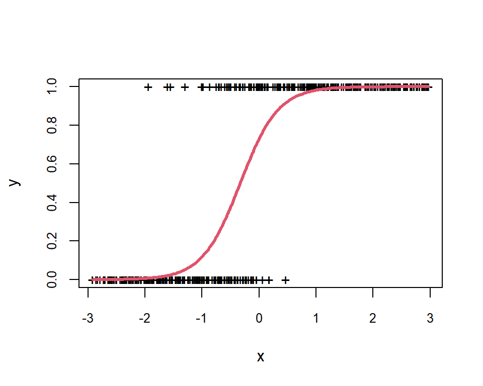

```r
sigmoid <- function(x) 1/(1 + exp(-x))

set.seed(0)
N.tr <- 400
w <- c(1, 3)
x <- sort(runif(N.tr, min = -3, max = 3))
theta <- sigmoid(cbind(rep(1, N.tr), x) %*% w)
y <- 1*(runif(N.tr) <= theta)
plot(x, y, pch = "+", cex.axis = 0.8)
lines(x, theta, col = 2, lwd = 3)
```

다음은 손실함수 계산과 경사하강법을 구현한 것이다.

```r
Loss <- function(w, x, y)
{
  eps <- 1.0e-12
  N.tr <- length(y)
  theta <- sigmoid(cbind(rep(1, N.tr), x) %*% w)
  theta <- pmin(pmax(theta, eps), 1 - eps)
  ans <- -mean(y*log(theta) + (1 - y)*log(1 - theta))

  return(ans)
}

GD.Logistic <- function(x, y, eta = 1, doplot = TRUE, tol = 1e-9, max.iter = 1000)
{
  # Initialization
  set.seed(123)
  w <- rnorm(2)

  N.tr <- length(y)
  iter <- 0
  x.tilde <- cbind(rep(1, N.tr), x)
  loss <- rep(NA, max.iter)
  w.trace <- matrix(NA, max.iter, 2)
  converged <- 0

  # Iteration
  while( iter < max.iter ) {
    iter <- iter + 1

    # Gradient
    tmp <- y - sigmoid(x.tilde %*% w)
    del <- cbind(tmp, tmp)
    gr <- colMeans(del * x.tilde)

    # Update
    w <- w + eta * gr
    w.trace[iter,] <- w

    loss[iter] <- Loss(w, x, y)
    if ( iter > 5 ) {
      if (abs(loss[iter] - loss[iter - 1]) < tol ) {
        converged <- 1
        break
      }
    }
  }
  loss <- loss[!is.na(loss)]
  w.trace <- na.omit(w.trace)

  if(doplot) {
    par(mfrow = c(1, 2))
    plot(loss, type = "b", col = "navy",
         xlab = "Iteration", ylab = "Loss")
    plot(w.trace, type = "b", col = "darkred",
         xlab = expression(w[0]), ylab = expression(w[1]))
  }

  return(list(w = w, loss = loss, w.trace = w.trace, iter = iter, converged = converged))
}
```

위에서 모의실험으로 생성한 데이터셋에 경사하강법을 적용해보자.

```r
res <- GD.Logistic(x, y)
```

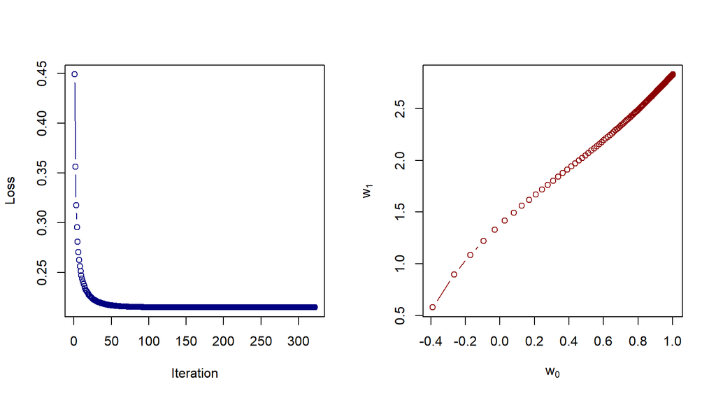

```r
res$iter
```

```
## [1] 322
```

```r
res$loss[res$iter]
```

```
## [1] 0.2151496
```

```r
res$w
```

```
##                 x
## 1.001884 2.831065
```

`glm()`을 사용한 결과와 비교해보자.

```r
res.glm <- glm(y ~ x, family = "binomial")
res.glm$coefficients
```

```
## (Intercept)           x
##    1.002651    2.832439
```

```r
Loss(res.glm$coefficients, x, y)
```

```
## [1] 0.2151496
```

학습된 로지스틱회귀식의 그래프를 확인해보자.

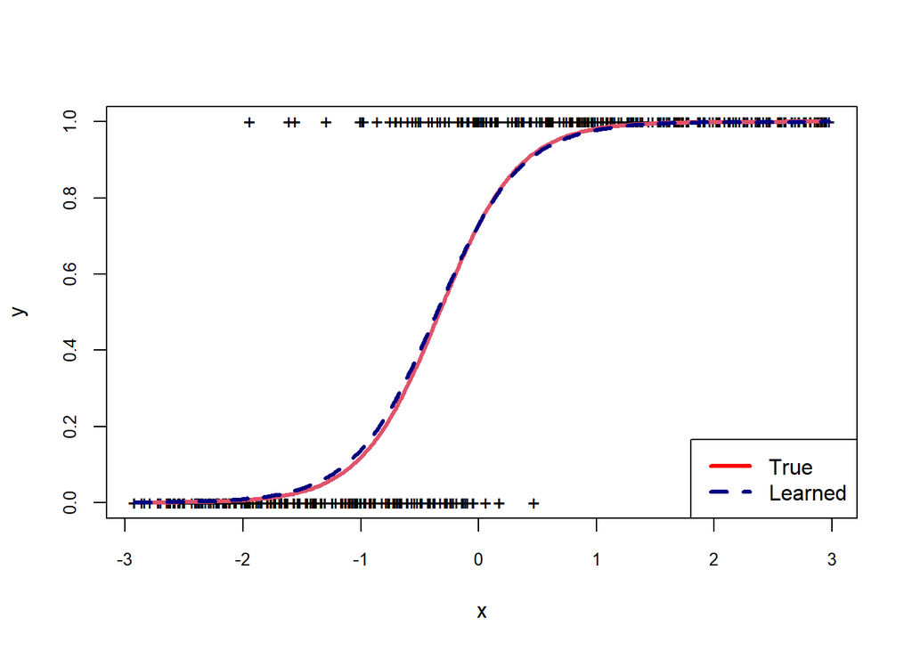

```r
plot(x, y, pch = "+", cex.axis = 0.8)
lines(x, theta, col = 2, lwd = 3)
lines(x, sigmoid(cbind(rep(1, N.tr), x) %*% res$w),
      col = "navy", lwd = 3, lty = 2)
legend("bottomright", c("True", "Learned"),
       lty = c(1, 2), lwd = c(3, 3), col = c("red", "navy"))
```

### 확률적경사하강법

위에서 살펴본 알고리즘은 업데이트가 일어날 때마다 전체 학습데이터를 사용해 그래디언트를 구하는 배치(batch) 알고리즘이다. 이 방식은 $N_{\sf tr}$이 엄청나게 큰 경우 $\sum_{n\in N_{\sf tr}}$의 계산에 비용이 많이 드는 문제가 있다. 이에 대한 대안으로 매 업데이트 시마다 그래디언트의 계산에 관측치 하나씩만 사용하는 소위 확률적 그래디언트 알고리즘이 있다. 즉, 각 $n \in I_{\sf tr}$에 대해
$$\boldsymbol{w} \,\leftarrow\, \boldsymbol{w} - \eta\cdot\nabla
L(\tilde{\boldsymbol y}_n, {\boldsymbol y}_n)\quad\Leftrightarrow\quad
\boldsymbol{w} \,\leftarrow\, \boldsymbol{w} + \eta\cdot\left\{ y_n -
\sigma\left(\tilde{\boldsymbol x}_n^\top \boldsymbol{w}
\right)\right\}\, \tilde{\boldsymbol x}_n$$

- 확률적경사하강(stochastic gradient descent, SGD) 알고리즘
  1. (초기화) 난수를 발생시켜 $\boldsymbol{w}$의 초기치를 정한다.
  2. (데이터 섞기) $I_{\sf tr}$을 셔플한다.
  3. (업데이트) 각 $n\in I_{\sf tr}$에 대해 순차적으로
     $$\boldsymbol{w} \,\leftarrow\, \boldsymbol{w} + \eta\cdot\left\{ y_n -
     \sigma\left(\tilde{\boldsymbol x}_n^\top \boldsymbol{w}
     \right)\right\}\, \tilde{\boldsymbol x}_n$$
     를 시행한다.
  4. (반복) 수렴할 때까지 단계 2 – 단계 3을 반복한다.

위 알고리즘에서 단계 2 – 단계 3을 완료하는 것을 하나의 **에포크(epoch)**를 마쳤다고 표현한다. 알고리즘 반복 횟수는 에포크 단위로 관리하는 것이 일반적이다. 다음은 로지스틱 회귀모형의 학습을 위한 확률적경사하강법을 구현한 것이다.

```r
SGD.Logistic <- function(x, y, eta = 0.003, doplot = TRUE, tol = 1e-9, max.epoch = 1000)
{
  # Initialization
  set.seed(123)
  w <- rnorm(2)
  N.tr <- length(y)
  epoch <- 0
  x.tilde <- cbind(rep(1, N.tr), x)
  loss <- rep(NA, max.epoch)
  w.trace <- matrix(NA, N.tr*max.epoch, 2)
  converged <- 0; count <- 0

  # Iteration
  while( epoch < max.epoch ) {
    epoch <- epoch + 1
    ind <- sample.int(N.tr)
    x.tilde.permuted <- x.tilde[ind,]
    y.permuted <- y[ind]
    for (n in 1:N.tr) {
      count <- count + 1
      # Gradient
      tmp <- y.permuted[n] - sigmoid(x.tilde.permuted[n,] %*% w)
      del <- c(tmp, tmp)
      gr <- del * x.tilde.permuted[n,]

      # Update
      w <- w + eta * gr
      w.trace[count,] <- w
    }
    loss[epoch] <- Loss(w, x, y)
    if ( epoch > 5 ) {
      if (max(abs(loss[epoch - 1] - loss[epoch])) < tol ) {
        converged <- 1
        break
      }
    }
  }

  loss <- loss[!is.na(loss)]
  w.trace <- na.omit(w.trace)

  if(doplot) {
    par(mfrow = c(1, 2))
    plot(loss, type = "b", col = "navy",
         xlab = "Epoch", ylab = "Loss")
    plot(w.trace, type = "l", col = "darkred",
         xlab = expression(w[0]), ylab = expression(w[1]))
  }

  return(list(w = w, loss = loss, epoch = epoch, converged = converged))
}
```

위에서 생성했던 데이터에 확률적경사하강법을 적용해보자.

```r
res <- SGD.Logistic(x, y)
```

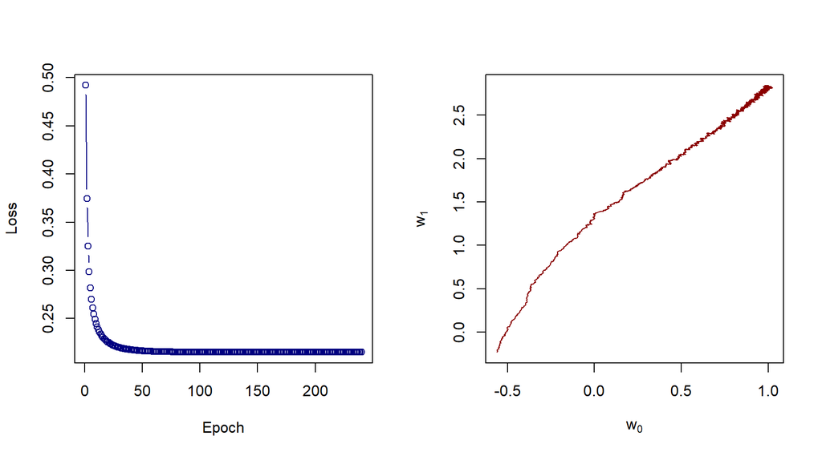

```r
res$epoch
```

```
## [1] 240
```

```r
res$loss[res$epoch]
```

```
## [1] 0.2151497
```

```r
res$w
```

```
##                 x
## 1.001171 2.829031
```

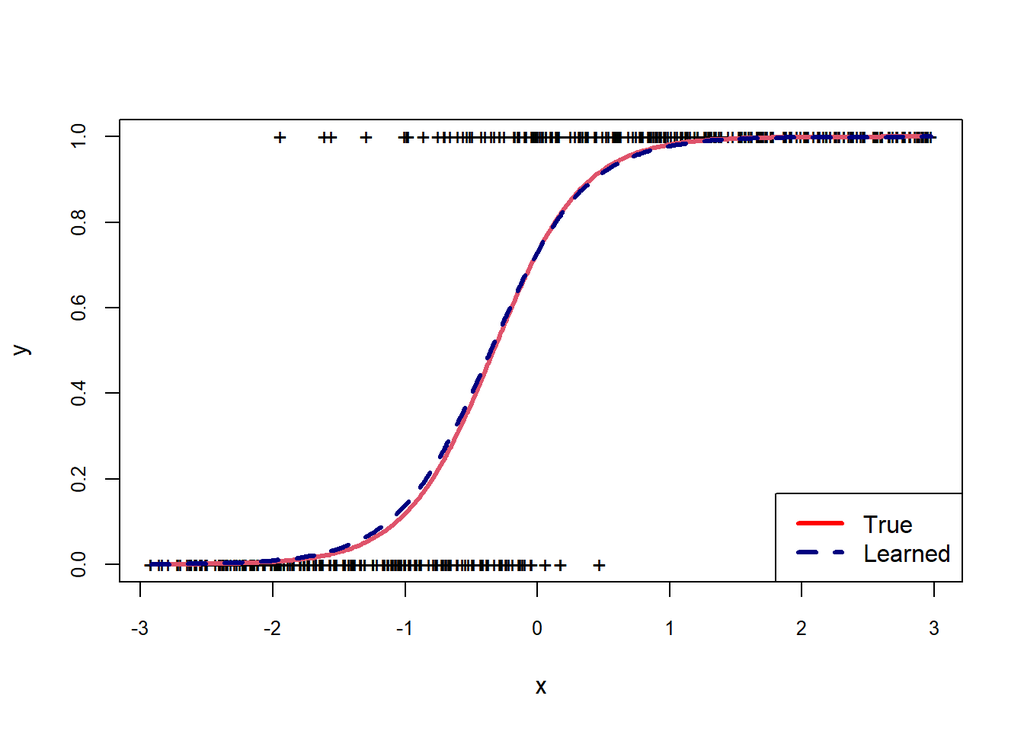

```r
plot(x, y, pch = "+", cex.axis = 0.8)
lines(x, theta, col = 2, lwd = 3)
lines(x, sigmoid(cbind(rep(1, N.tr), x) %*% res$w),
      col = "navy", lwd = 3, lty = 2)
legend("bottomright", c("True", "Learned"),
       lty = c(1, 2), lwd = c(3, 3), col = c("red", "navy"))
```

## 로지스틱 회귀모형을 이용한 분류 (클래스 예측)

### 시험데이터

$${\cal D}_{\sf test} = \{({\boldsymbol x}_i, y_i)\in{\cal D}\,|\, i \in
I_{\sf test}\}$$
단, $I_{\sf test} = I\setminus I_{\sf tr}$이다.

### 예측공식

적절한 절단값 $c\in(0, 1)$를 정한 후,
$$I(\tilde{y}_n \ge c) = \begin{cases} 1 & \text{ if }\tilde{y}_n \ge
c \\ 0 & \text{ if } \tilde{y}_n < c \end{cases} \quad (n\in
I_{\sf test})$$

- 로지스틱회귀모형에 기반한 분류기는 선형분류기(linear classifier): $n\in I_{\sf test}$ 일 때,
  $$\tilde{y}_n \ge c
  \,\Leftrightarrow\,
  \sigma\left(w_0 + w_1 x_{n,1} + \cdots + w_d x_{n,d}\right) \ge c
  \,\Leftrightarrow\,
  w_0 + w_1 x_{n,1} + \cdots + w_d x_{n,d} \ge c'$$
  단, $c' = {\sf logit}(c)$이다.

### 예측 결과 평가

#### 혼동행렬에 기반한 성능 측도들

$$\begin{eqnarray*}
{\rm Accuracy} &=& \frac{\rm TP + TN}{N} \\
{\rm Precision} &=& \frac{\rm TP}{\rm TP + FP}\\
{\rm Recall} &=& \frac{\rm TP}{\rm TP + FN} = {\rm
Sensitivity}\\
{\rm Specificity} &=& \frac{\rm TN}{\rm TN + FP}
\end{eqnarray*}$$

```r
HarmonicMean <- function(a, b) 2*a*b/(a + b)

AccuracyMeasures <- function(pred, actual, cutoff = 0.5) {
  ctable <- table(Actual = actual,
                  Predicted = 1*(pred >= cutoff))
  cat("Confusion matrix: \n")
  print(ctable)
  cat("\n")
  accuracy <- round(sum(diag(ctable))/sum(ctable), 4)
  specificity <- round(ctable[1, 1]/sum(ctable[1,]), 4)
  precision <- round(ctable[2, 2]/sum(ctable[,2]), 4)
  recall <- round(ctable[2, 2]/sum(ctable[2,]), 4)
  f1 <- round(HarmonicMean(precision, recall), 4)
  data.frame(Accuracy = accuracy,
             Specificity = specificity,
             Sensitivity = recall,
             Precision = precision,
             Recall = recall,
             F1 = f1)
}
```

#### 절단값

보통 이항분류기는 예측된 클래스 확률에 적절한 절단값(cut-off, cut-off value, 혹은 기준값 criterion value)을 적용해 분류를 실시하기 때문에, 절단값의 크기에 따라 분류 결과와 그 성능이 달라진다. 즉, 기준값을 크게 정하면 specificity는 좋아지지만 sensitivity가 떨어지고, 작게 잡으면 반대의 경우가 된다. 직관적으로 예측확률에 대해 0.5를 절단값으로 적용하는 것이 자연스러워 보이지만, 자료의 불균형이 심하거나 오분류 시 감당해야 하는 비용(리스크)를 감안해 절단값을 결정해야 한다.

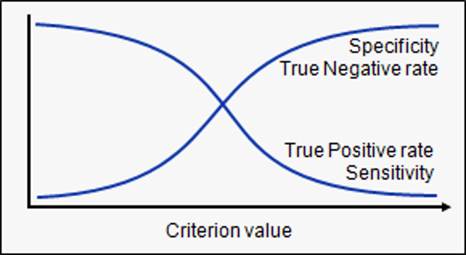

#### ROC 곡선

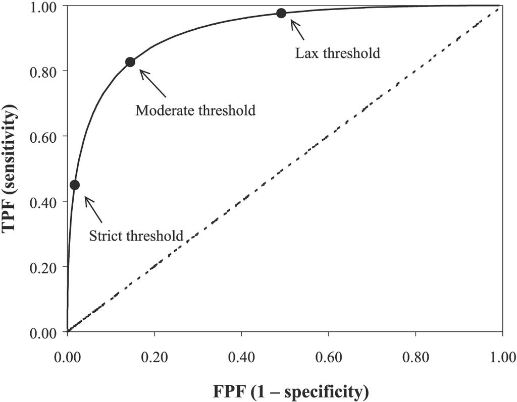

```r
ROC.plot <- function(Pred, Actual)
  # Pred: predicted class probability
  # Actual: indicator for actual class
{
  require(ROCR)
  Prediction <- prediction(Pred, Actual)
  Perf <- performance(Prediction,
                      measure = "tpr", x.measure = "fpr")
  plot(Perf, main = "ROC curve", cex.axis = 0.7)
  abline(0, 1, lty = 2)
  auc <- performance(Prediction, "auc")@y.values[[1]]
  text(0.7, 0.5, paste("AUC = ", round(auc, 4)))

  return(list(AUC = auc))
}
```

## 예제 데이터 분석: `adult`

1. 데이터 읽기

```r
adult <- read.csv(file = "./dat/adult.csv", stringsAsFactors = TRUE)
```

```r
summary(adult)
```

```
##       age                    workclass         fnlwgt
##  Min.   :17.00    Private         :22696   Min.   :  12285
##  1st Qu.:28.00    Self-emp-not-inc: 2541   1st Qu.: 117832
##  Median :37.00    Local-gov       : 2093   Median : 178363
##  Mean   :38.58    ?               : 1836   Mean   : 189782
##  3rd Qu.:48.00    State-gov       : 1297   3rd Qu.: 237055
##  Max.   :90.00    Self-emp-inc    : 1116   Max.   :1484705
##                  (Other)          :  981
##          education     education_num                  marital_status
##   HS-grad     :10501   Min.   : 1.00    Divorced             : 4443
##   Some-college: 7291   1st Qu.: 9.00    Married-AF-spouse    :   23
##   Bachelors   : 5354   Median :10.00    Married-civ-spouse   :14976
##   Masters     : 1723   Mean   :10.08    Married-spouse-absent:  418
##   Assoc-voc   : 1382   3rd Qu.:12.00    Never-married        :10682
##   11th        : 1175   Max.   :16.00    Separated            : 1025
##  (Other)      : 5134                    Widowed              :  993
##             occupation            relationship                    race
##   Prof-specialty :4140    Husband       :13193    Amer-Indian-Eskimo:  311
##   Craft-repair   :4099    Not-in-family : 8304    Asian-Pac-Islander: 1039
##   Exec-managerial:4066    Other-relative:  981    Black             : 3124
##   Adm-clerical   :3769    Own-child     : 5068    Other             :  271
##   Sales          :3650    Unmarried     : 3446    White             :27815
##   Other-service  :3295    Wife          : 1568
##  (Other)         :9541
##       sex         capital_gain    capital_loss     hours_per_week
##   Female:10771   Min.   :    0   Min.   :   0.00   Min.   : 1.00
##   Male  :21789   1st Qu.:    0   1st Qu.:   0.00   1st Qu.:40.00
##                  Median :    0   Median :   0.00   Median :40.00
##                  Mean   : 1078   Mean   :  87.31   Mean   :40.44
##                  3rd Qu.:    0   3rd Qu.:   0.00   3rd Qu.:45.00
##                  Max.   :99999   Max.   :4356.00   Max.   :99.00
##
##         native_country      wage
##   United-States:29169    <=50K:24719
##   Mexico       :  643    >50K : 7841
##   ?            :  583
##   Philippines  :  198
##   Germany      :  137
##   Canada       :  121
##  (Other)       : 1709
```

2. 훈련데이터와 시험데이터 쪼개기 (70:30)

```r
set.seed(0)
print(N <- nrow(adult))
```

```
## [1] 32560
```

```r
print(N.tr <- round(0.7*N))
```

```
## [1] 22792
```

```r
tr <- sort(sample(1:N, N.tr, replace = FALSE))
adult.tr <- adult[tr,]
adult.te <- adult[-tr,]
```

3. 로지스틱 회귀모형 학습: `glm()` 사용

```r
glm.fit <- glm(wage ~ age + workclass + education
               + occupation + race + sex
               + capital_gain + hours_per_week,
               family = "binomial",
               data = adult.tr)
#summary(glm.fit)
```

4. 예측 성능 확인

```r
Predicted.glm <- predict(glm.fit, newdata = adult.te, type = "response")
cutoff <- 0.5
Actual <- 1*(adult.te$wage == " >50K")
AccuracyMeasures(pred = Predicted.glm, actual = Actual)
```

```
## Confusion matrix:
##       Predicted
## Actual    0    1
##      0 6951  383
##      1 1317 1117
```

```
##   Accuracy Specificity Sensitivity Precision Recall     F1
## 1    0.826      0.9478      0.4589    0.7447 0.4589 0.5679
```

**기준값 = 0.5?**

```r
cutoffs <- seq(from = 0.3, to = 0.7, by = 0.1)
for (cutoff in cutoffs) {
  cat("[Cutoff = ", cutoff, "]\n\n", sep = "")
  print(AccuracyMeasures(pred = Predicted.glm, actual = Actual, cutoff = cutoff))
  cat("----------------------------------------------------------\n\n")
}
```

```
## [Cutoff = 0.3]
##
## Confusion matrix:
##       Predicted
## Actual    0    1
##      0 6190 1144
##      1  784 1650
##
##   Accuracy Specificity Sensitivity Precision Recall     F1
## 1   0.8026       0.844      0.6779    0.5906 0.6779 0.6312
## ----------------------------------------------------------
##
## [Cutoff = 0.4]
##
## Confusion matrix:
##       Predicted
## Actual    0    1
##      0 6684  650
##      1 1084 1350
##
##   Accuracy Specificity Sensitivity Precision Recall     F1
## 1   0.8225      0.9114      0.5546     0.675 0.5546 0.6089
## ----------------------------------------------------------
##
## [Cutoff = 0.5]
##
## Confusion matrix:
##       Predicted
## Actual    0    1
##      0 6951  383
##      1 1317 1117
##
##   Accuracy Specificity Sensitivity Precision Recall     F1
## 1    0.826      0.9478      0.4589    0.7447 0.4589 0.5679
## ----------------------------------------------------------
##
## [Cutoff = 0.6]
##
## Confusion matrix:
##       Predicted
## Actual    0    1
##      0 7134  200
##      1 1572  862
##
##   Accuracy Specificity Sensitivity Precision Recall     F1
## 1   0.8186      0.9727      0.3541    0.8117 0.3541 0.4931
## ----------------------------------------------------------
##
## [Cutoff = 0.7]
##
## Confusion matrix:
##       Predicted
## Actual    0    1
##      0 7231  103
##      1 1802  632
##
##   Accuracy Specificity Sensitivity Precision Recall     F1
## 1    0.805       0.986      0.2597    0.8599 0.2597 0.3989
## ----------------------------------------------------------
```

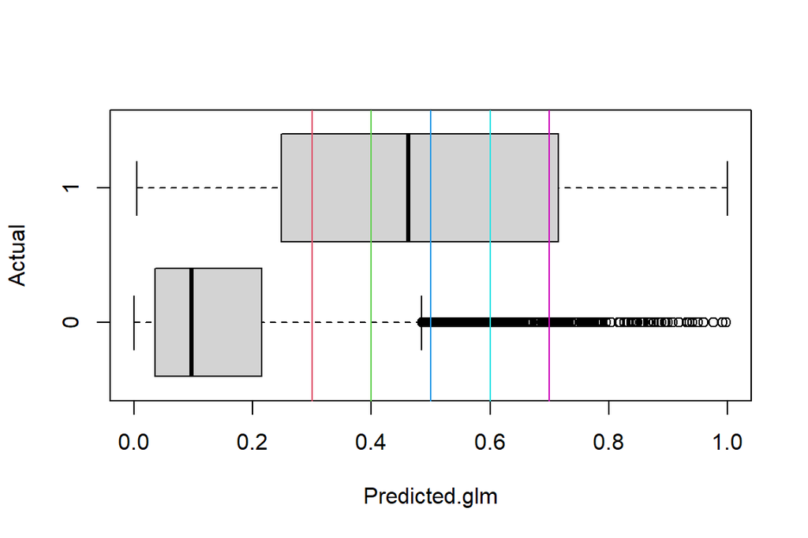

```r
boxplot(Predicted.glm ~ Actual, horizontal = TRUE)
abline(v = cutoffs, col = 2:6)
```

**ROC 곡선**

```r
auc <- ROC.plot(as.vector(Predicted.glm), Actual)
tmp <- AccuracyMeasures(pred = Predicted.glm, actual = Actual, cutoff = 0.3)
```

```
## Confusion matrix:
##       Predicted
## Actual    0    1
##      0 6190 1144
##      1  784 1650
```

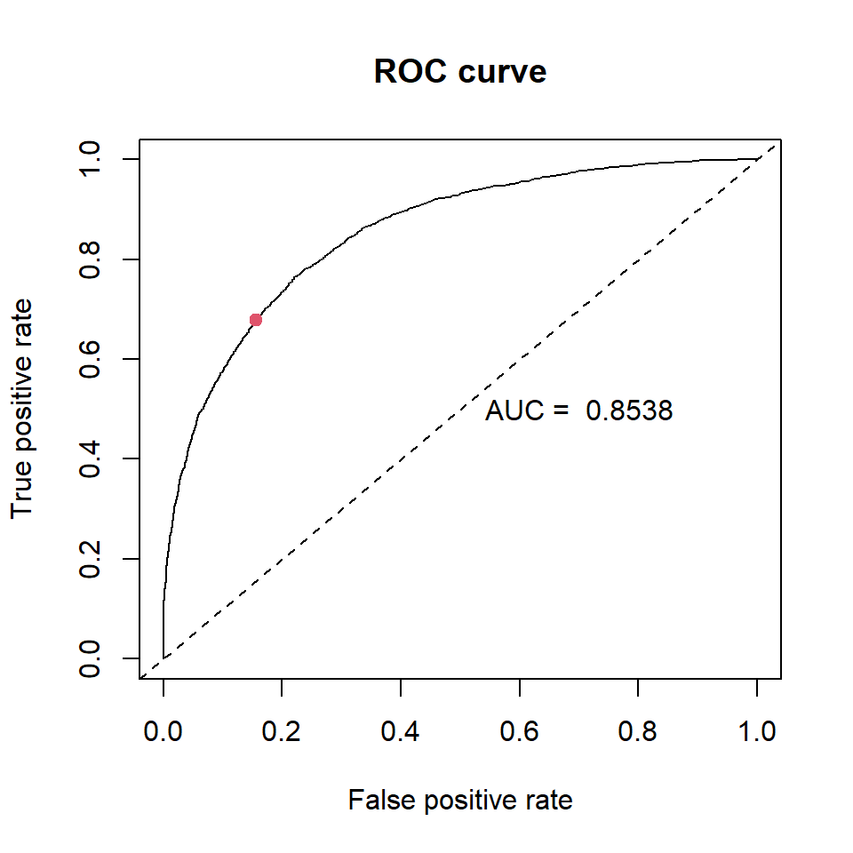

```r
with(tmp, points(1 - Specificity, Sensitivity, pch = 19, col = 2))
```